# Befolkningsutvecklingen i Malung-Sälen

Befolkningsutvecklingen i Malung-Sälen  
- en kort analys

Rapporten är skapad av Samhällsanalys, Region Dalarna  
Senast uppdaterad: 2025-02-28

# Sammanfattning

Syftet med den här korta analysen är att undersöka Malung-Sälens befolkningsutveckling. Ett antal viktiga slutsatser sammanfattas här:

- För första gången sedan 2018 minskade folkmängden i Malung-Sälen år 2024. Detta berodde i första hand på att färre flyttade till kommunen från andra delar av Sverige (netto).
- Det föddes lika många barn i Malung-Sälen år 2024 som året innan, men fler än åren dessförinnan.
- En stramare nationell migrationspolitik gör att färre invandrar till Sverige än tidigare, vilket även påverkar inflyttningen till Malung-Sälen. Att invandringsöverskottet ändå ökade i Malung-Sälen år 2024 kan sannolikt delvis förklaras med att personer födda i Ukraina sedan juni 2024 haft möjlighet att ansöka om att bli folkbokförda i Sverige.
- Den största utflyttningen från kommunen inrikes (netto) skedde i åldersgruppen 0-19 år.

För mer info om statistiken, klicka på rutan nedan:

**Mer information om statistiken**

I folkmängden som SCB publicerar ingår personer som är folkbokförda i landet. För att den som flyttar till Sverige ska bli folkbokförd ska personen ha för avsikt och rätt att stanna i Sverige i minst ett år. För personer som inte är medborgare i ett EU-land innebär det att det krävs ett uppehållstillstånd som gäller minst 12 månader för att bli folkbokförd. Till följd av Rysslands invasion av Ukraina den 24 februari 2022 har Europeiska unionen (EU) beslutat att aktivera massflyktsdirektivet, vilket innebär att personer från Ukraina utan individuell prövning ska erbjudas tidsbegränsat uppehålls- och arbetstillstånd inom EU. Personer som får uppehållstillstånd enligt massflyktsdirektivet ska i regel inte bli folkbokförda och ingå i den officiella befolkningsstatistiken. Läs mer här. Sedan juni 2024 har dock personer födda i Ukraina haft möjlighet att ansöka om att bli folkbokförda i Sverige [(SCB)](https://www.scb.se/hitta-statistik/statistik-efter-amne/befolkning-och-levnadsforhallanden/befolkningens-sammansattning-och-utveckling/befolkningsstatistik/pong/statistiknyhet/namnlos/).

Under 2023 inledde Skatteverket ett arbete med att granska registret över folkbokförda. Det förde med sig att SCB avregistrerade flera tusen folkbokförda personer som visade sig inte längre bo i Sverige. I folkbokföringen har dessa registrerats som utvandrade till okänt utvandringsland. Detta arbete fortsatte under 2024. Läs mer [här](https://www.scb.se/pressmeddelande/sverige-gar-mot-lagsta-befolkningsokningen-pa-manga-ar/).

All data som används i rapporten är offentlig och finns under kategorin befolkning i SCB:s [Statistikdatabas](https://www.statistikdatabasen.scb.se/pxweb/sv/ssd/). Där finns även data för exempelvis befolkningsutvecklingen under 2025 på månadsbasis som publiceras löpande, något som inte behandlas i denna rapport.

# 1 Hur har befolkningen förändrats?

År 2024 minskade dock folkmängden med 6 personer.

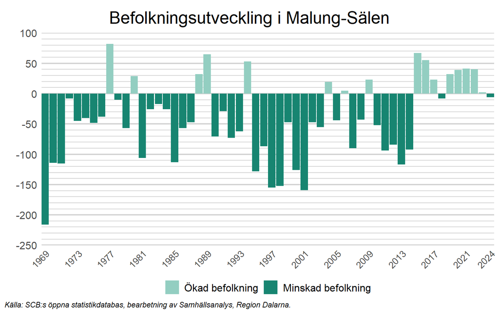

I fortsättningen av denna korta analys delas befolkningsutveckling upp i dess komponenter, födelsenetto, dvs. nettot av födda och döda, och flyttnetto, dvs. nettot av inrikes och utrikes flyttar.

# 2 Födelsenetto

En trend är att det dör färre personer i Malung-Sälen idag än det gjorde längre tillbaka i tiden. Normalt dör mellan 110 och 140 personer årligen i kommunen, att jämföra med närmare 200 personer under några år i början av 1990-talet. Detta kan delvis förklaras av att färre idag bor i kommunen, men den främsta anledningen är framsteg inom det medicinska området. Den förväntade livslängden har helt enkelt ökat över tid.

Även när det gäller antalet födslar är den långsiktiga trenden negativ. Under det sena 1980-talet och det tidigt 1990-talet föddes ofta närmare 150 barn i Malung-Sälen per år, men en tydlig negativ trend inleddes i samband med finanskrisen i början på 1990-talet. Under 2000-talet har antalet födda legat på en relativt stabil nivå, även om variationen kan vara stor från år till år. 2024 föddes 89 barn, viket var lika många som året innan men något fler än åren dessförinnan. På den punkten skiljer sig Malung-Sälen från riket i stort, då barnafödandet i Sverige per kvinna 2024 var det lägsta som uppmätts.

Nettot mellan födda och döda, se de svarta linjerna i diagrammet nedan, har varit negativt i Malung-Sälen under varje år sedan slutet på 1960-talet. Hur många invånare som kommunen tappar på grund av det varierar relativt mycket mellan åren. År 2024 minskade befolkningen med 41 personer till följd av ett negativt födelsenetto.

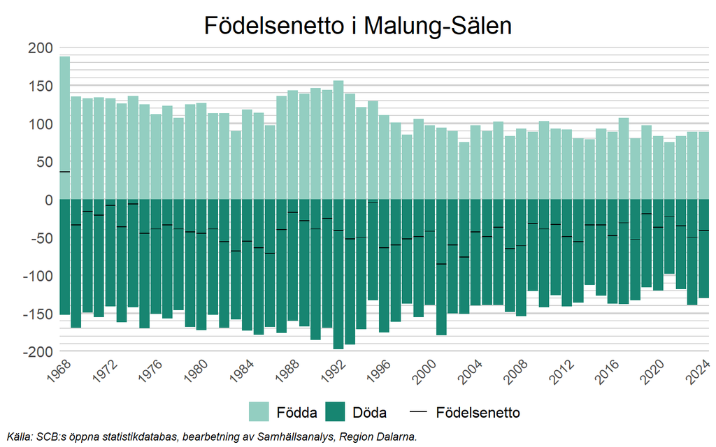

# 3 Flyttnetto

Den andra komponenten som styr befolkningsutvecklingen är det så kallade flyttnettot. Detta kan i sin tur delas upp i två komponenter, inrikes och utrikes flyttar. I det här avsnittet är fokus först på flyttnettot, innan de två komponenterna undersöks.

Historiskt varierade nettot mellan antalet personer som flyttade till och från Malung-Sälen relativt mycket mellan åren och var ofta negativt. Sedan mitten på 2010-talet har trenden dock förändrats och flyttnettot har varit positivt under varje år sedan 2015. År 2024 flyttade 38 personer till kommunen (netto), vilket var något färre än åren innan.

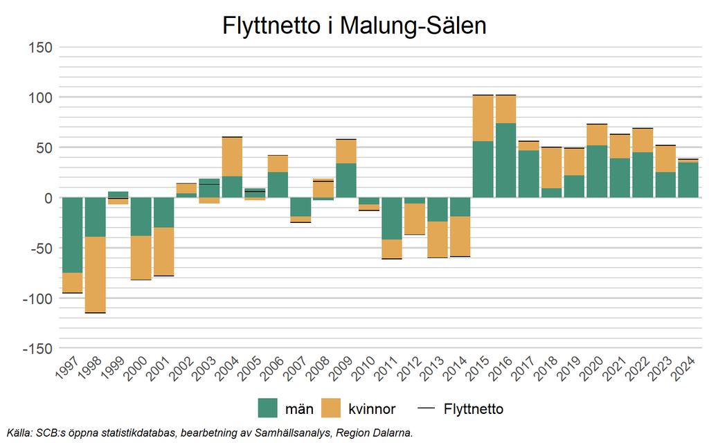

## 3.1 Utrikes flyttnetto

Som berördes i föregående avsnitt, har flyttnettot till Malung-Sälen varit positivt under varje år sedan 2015, vilket under framförallt 2016 och några år däromkring kan förklaras med att invandringen då var hög. I slutet av 1990-talet var invandringen låg eller till och med negativ under flera år (fler utvandrade än invandrade), men därefter skedde en gradvis ökning innan den stora toppen 2016. Därefter har invandringen minskat, men varit förhållandevis hög under vissa år.

Efter att ha varit relativt lågt 2023, ökade det utrikes flyttnettot år 2024 till 69 personer. Detta kan sannolikt delvis förklaras med att personer födda i Ukraina sedan juni 2024 haft möjlighet att ansöka om att bli folkbokförda i Sverige (se [SCB](https://www.statistikdatabasen.scb.se/pxweb/sv/ssd/START__BE__BE0101__BE0101E/FolkmRegFlandK/table/tableViewLayout1/)). Läs mer i den klickbara rutan “mer information om statistiken” ovan.

Värt att notera är även att Skattemyndigheten under 2023 påbörjade en avregistrering av utvandrade, vilket kan få viss påverkan på utvandringen såväl 2023 som 2024 (se informationsrutan under avsnittet introduktion ovan). Den viktigaste anledningen till att invandringen generellt är lägre idag än åren från mitten av 2010-talet är dock sannolikt en stramare nationell migrationspolitik.

Generellt invandrar ungefär lika många kvinnor och män till Malung-Sälen.

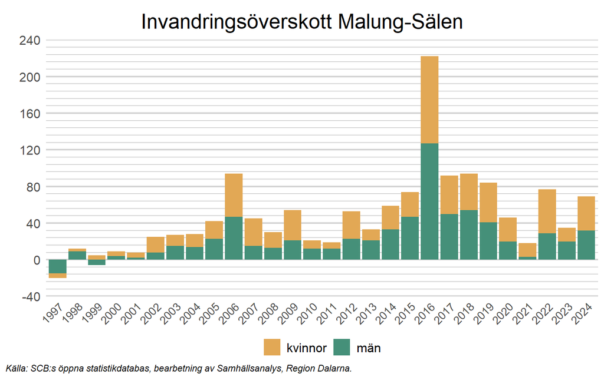

## 3.2 Inrikes flyttnetto

Det inrikes flyttnettot till Malung-Sälen varierar relativt mycket mellan åren, men har varit negativt under en majoritet av åren sedan slutet på 1990-talet. På senare år har dock fler personer flyttat till än från Malung-Sälen inrikes vid flera tillfällen, då framförallt under åren runt Corona-pandemin (2020 och 2021). År 2024 flyttade 31 personer netto från kommunen inrikes, vilket var det största negativa nettot sedan 2019.

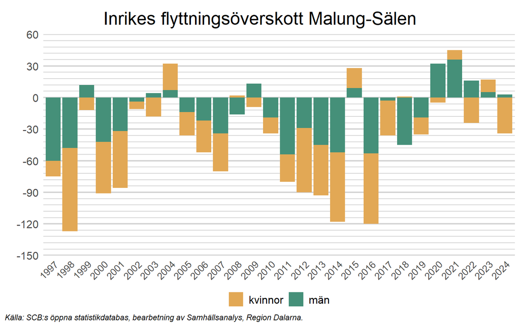

För att bättre förstå för vilka som flyttar till och från kommunen inrikes, delas de som flyttar härnäst upp efter ålder. Normalt är personer mest benägna att flytta till en annan ort när de är i 20-års åldern, innan flyttandet gradvis avtar.

### 3.2.1 Uppdelat på ålder

Ett mönster är att det till Malung-Sälen flyttar fler personer mellan 30 och 39 år än de i samma åldersgrupp som flyttar därifrån, dvs. kommunens invånarantal i den åldersgruppen ökar på grund av inrikes flyttar. Under 2024 minskade dock det inrikes flyttnettot i åldersgruppen tydligt, från 19 personer till blott 1 person.

Bland de åldersgrupper som redovisas i diagrammet nedan skedde den största utflyttningen år 2024 i gruppen som är under 20 år (-20 personer). Detta var en tydlig förändring jämfört med året innan, när nettot i åldersgruppen var positivt. Även bland personer i åldersgruppen 20-29 år var det inrikes flyttnettot negativt år 2024.

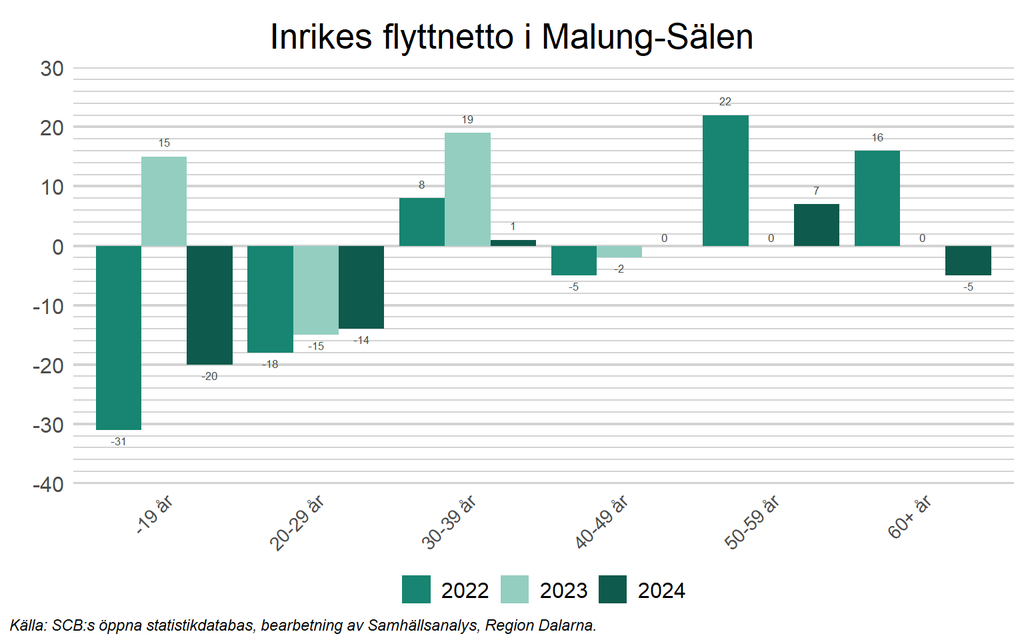

Om fokus enbart läggs på åldersgruppen 20-29 år, blir det tydligt att det i normala fall flyttar fler unga vuxna från än till kommunen inrikes. Historiskt varierar det inrikes flyttnettot i åldersgruppen mellan åren, vilket exempelvis kan bero på att olika årskullar av barn är olika stora. År 2024 flyttade 14 personer fler i åldersgruppen 20-29 år från än till kommunen inrikes, vilket var något färre än åren innan.

I Dalarna som helhet flyttade fler i åldersgruppen ut än in under 2024, vilket även gäller de flesta av länets kommuner.

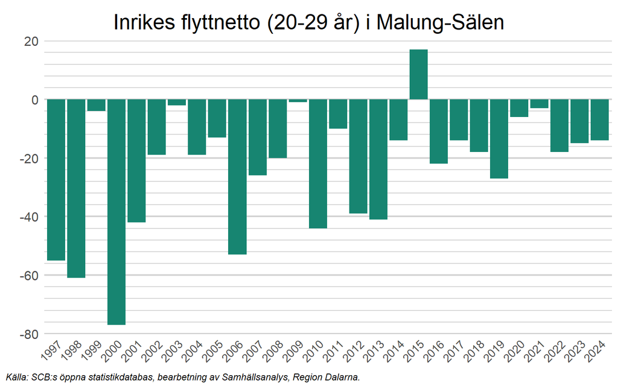

### 3.2.2 Uppdelat på bakgrund

*Observera att statistik i detta avsnitt uppdateras först i slutet av mars.*

För att ytterligare förtydliga vilka som flyttar till och från Malung-Sälen inrikes, delas de i detta avsnitt upp efter sin bakgrund, inrikes eller utrikes födda.

Tydligt är att en del av de som invandrade till Malung-Sälen under framförallt mitten på 2010-talet flyttade därifrån till andra delar av Sverige under åren därefter. Det inrikes flyttnettot för gruppen utrikes födda har varit negativt varje år sedan 2016. Bland de som är födda i Sverige är bilden annorlunda. Under slutet av 00-talet och början av 2010-talet flyttade många i den gruppen från Malung-Sälen till andra delar av Sverige, men den trenden vände 2017. Därefter har det inrikes flyttnettot varit positivt för gruppen mer eller mindre varje år. 2023 flyttade 48 personer födda i Sverige till kommunen inrikes (netto), vilket var fler än året innan.

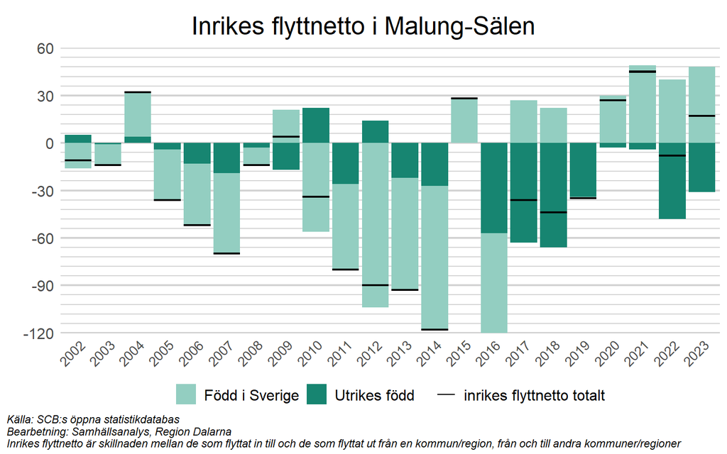

I nästa avsnitt är fokus istället på framtiden. Hur kommer Malung-Sälens folkmängd att utvecklas fram till 2033?

# 4 Vad händer i framtiden?

För en djupare förståelse runt hur SCB gör befolkningsprognoser, se motsvarande avsnitt i rapporten för hela Dalarnas län. Det viktigaste att ha i åtanke är att ingen hänsyn tas i prognoserna till planerat bostadsbyggande, företagsetableringar eller andra framtida mål och förutsättningar som kommunerna har i sina planer.

I diagrammet nedan visas befolkningsutvecklingen i Malung-Sälen fram till 2033 uppdelat på åldersgrupper, enligt SCB:s prognos från juni 2024 (se [SCB, 2024](https://www.statistikdatabasen.scb.se/pxweb/sv/ssd/START__BE__BE0401__BE0401A/BefProgRegFakN/)), vilket är den senaste som myndigheten publicerat offentligt på kommunal nivå. Notera att diagrammet kan skilja sig åt jämfört med motsvarande diagram i förra årets rapport. Detta eftersom befolkningen 2033 enligt SCBs prognos jämförs med den faktiska befolkningen vid slutet av 2024 i diagrammet nedan. I förra årets rapport jämfördes prognosen för 2033 med den faktiska befolkningen vid slutet av 2023.

- Malung-Sälens befolkning prognostiseras att minska med ungefär 130 personer till 2033, jämfört med 2024. I SCB:s föregående prognos, som släpptes 2022, prognostiserades en minskning på ungefär 400 personer fram till 2033, jämfört med 2021 (se [SCB, 2022](https://www.statistikdatabasen.scb.se/pxweb/sv/ssd/START__BE__BE0401__BE0401B/BefProgRegFakN22/table/tableViewLayout1/)).
- Den största minskningen sker i det som brukar benämnas arbetsför ålder, 20-64 år, som prognostiseras minska med ungefär 210 personer.
- I åldergruppen 80+ förväntas befolkning att öka med ungefär 220 personer fram till 2033. Detta hänger sannolikt samman med att den förväntade livslängden fortsätter öka och att den stora gruppen “baby-boomers” börjar komma upp i 80-års åldern.
- Även i åldersgruppen 0-19 år sker en relativt stor minskning av befolkningen, knappt 140 personer.

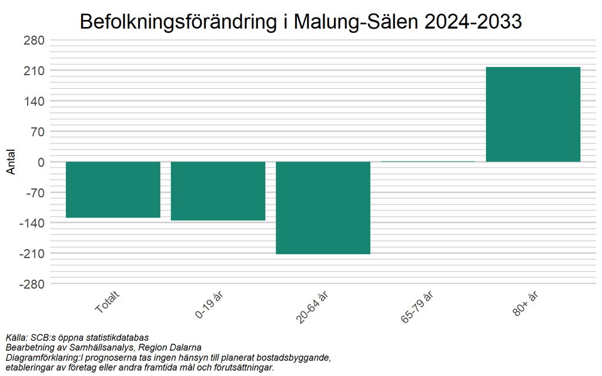